# Untitled

Richard

2023-07-24

# Chargement des packages

```r
library(readxl)
library(dplyr)
library(gtsummary)
library(gt)
library(sf)
library(leaflet)
library(ggplot2)
library(flextable)
library(ggspatial)
library(broom)
library(questionr)
```

# Partie 1

## 1. Préparation des données

### 1.1 Decription

### 1.2 Importation et mise en forme

• Importons la base de données dans un objet de type data.frame nommé projet

```r
projet <- read_excel("Bases/Base_Partie 1.xlsx")
```

• Faites un tableau qui resume les valeurs manquantes par variable

```r
df = data.frame(variables = colnames(projet),Valeurs_manquantes = colSums(is.na(projet)))
df %>% gt()
```

| variables | Valeurs_manquantes |
| --- | --- |
| key | 0 |
| q1 | 0 |
| q2 | 0 |
| q23 | 0 |
| q24 | 0 |
| q24a_1 | 0 |
| q24a_2 | 0 |
| q24a_3 | 0 |
| q24a_4 | 0 |
| q24a_5 | 0 |
| q24a_6 | 0 |
| q24a_7 | 0 |
| q24a_9 | 0 |
| q24a_10 | 0 |
| q25 | 0 |
| q26 | 0 |
| q12 | 0 |
| q14b | 1 |
| q16 | 1 |
| q17 | 131 |
| q19 | 120 |
| q20 | 0 |
| filiere_1 | 0 |
| filiere_2 | 0 |
| filiere_3 | 0 |
| filiere_4 | 0 |
| q8 | 0 |
| q81 | 0 |
| gps_menlatitude | 0 |
| gps_menlongitude | 0 |
| submissiondate | 0 |
| start | 0 |
| today | 0 |

• Vérifions s’il y a des valeurs manquantes pour la variable key dans la base projet. Si oui, nous identifierons la (ou les) PME concernée(s).

### 1.3 Création de variables

• Renommons les variables

```r
# q1 en region, q2 en déparement et q23 en sexe
projet <- projet %>%
  rename(region = q1, departement = q2, sexe = q23)
```

• Créeons la variable sexe_2 vallant 1 si sexe égale à Femme et 0 sinon

```r
projet <- projet %>%
  mutate(sexe_2 = ifelse(sexe == "Femme", 1, 0))
```

• Création du data.frame “langues”

```r
langues <- projet %>%
  select(key, starts_with("q24a_"))
```

• Création de la variable “parle”

```r
langues <- langues %>%
  mutate(parle = rowSums(.[2:ncol(.)]))
```

• Sélection des variables “key” et “parle”

```r
langues <- langues %>%
  select(key, parle)
```

• Mergons les data.frame “projet” et “langues”

```r
projet <- projet %>%
  left_join(langues, by = "key")
```

## 2. Statistiques descriptives

Il nous est demandé la répartion des PME suivant:

• le sexe

• le niveau d’instruction

• le statut juridique

• le propriétaire/locataire

• le statut juridique et le sexe

• le niveau d’instruction et le sexe

• Propriétaire/locataire suivant le sexe

Nous résumons ces répartitions dans un seul tableau avec l’analyse univariée et l’anlyse buvariée

```r
# Répartition des PME suivant le sexe, le niveau d'instruction,
# le statut juridique et le propriétaire locataire
tbl1 <- projet %>% tbl_summary(include = c("sexe", "q25", "q12", "q81"))

# Répartition des PME suivant le statut juridique et le sexe,
# le niveau d’instruction et le sexe,   Propriétaire/locataire
# et le sexe
tbl2 <- projet %>% tbl_summary(
  include = c("q25", "q12", "q81"),
  by ="sexe", label=list(q12~ "Statut juridique",
                         q25~ "Niveau d'instruction",
                         q81~ "Propriétaire/locataire")) %>%
  add_overall(last = TRUE) %>%
  modify_header(label ~ "**Caractéristiques**") %>%
  modify_spanning_header(all_stat_cols() ~ "**Sexe**") %>%
  bold_labels()

## Empillement l'une sur l'autre
tbl_stack(
  list(tbl1, tbl2),
  group_header = c("Analyse univariée", "Analyse bivarée"),
  quiet = TRUE )
```

| **Characteristic** | **N = 250**<sup>1</sup> | **Sexe** **Femme**, N = 191<sup>1</sup> | **Sexe** **Homme**, N = 59<sup>1</sup> |
| --- | --- | --- | --- |
| Analyse univariée |  |  |  |
| sexe |  |  |  |
| Femme | 191 (76%) |  |  |
| Homme | 59 (24%) |  |  |
| q25 |  |  |  |
| Aucun niveau | 79 (32%) |  |  |
| Niveau primaire | 56 (22%) |  |  |
| Niveau secondaire | 74 (30%) |  |  |
| Niveau Superieur | 41 (16%) |  |  |
| q12 |  |  |  |
| Association | 6 (2.4%) |  |  |
| GIE | 179 (72%) |  |  |
| Informel | 38 (15%) |  |  |
| SA | 7 (2.8%) |  |  |
| SARL | 13 (5.2%) |  |  |
| SUARL | 7 (2.8%) |  |  |
| q81 |  |  |  |
| Locataire | 24 (9.6%) |  |  |
| Propriétaire | 226 (90%) |  |  |
| Analyse bivarée |  |  |  |
| Niveau d'instruction |  |  |  |
| Aucun niveau | 79 (32%) | 70 (37%) | 9 (15%) |
| Niveau primaire | 56 (22%) | 48 (25%) | 8 (14%) |
| Niveau secondaire | 74 (30%) | 56 (29%) | 18 (31%) |
| Niveau Superieur | 41 (16%) | 17 (8.9%) | 24 (41%) |
| Statut juridique |  |  |  |
| Association | 6 (2.4%) | 3 (1.6%) | 3 (5.1%) |
| GIE | 179 (72%) | 149 (78%) | 30 (51%) |
| Informel | 38 (15%) | 32 (17%) | 6 (10%) |
| SA | 7 (2.8%) | 1 (0.5%) | 6 (10%) |
| SARL | 13 (5.2%) | 2 (1.0%) | 11 (19%) |
| SUARL | 7 (2.8%) | 4 (2.1%) | 3 (5.1%) |
| Propriétaire/locataire |  |  |  |
| Locataire | 24 (9.6%) | 16 (8.4%) | 8 (14%) |
| Propriétaire | 226 (90%) | 175 (92%) | 51 (86%) |

<sup>1</sup> n (%)

# 3 Cartographie

• Transformation du data.frame en données géographiques dont l’objet est nommé projet_map

```r
# Chargement des données de la carte du Sénégal
# Nous lisons le fichier contenant la carte du Sénégal et le stockons
# dans la variable "senegal"
senegal = st_read("Bases/gadm41_SEN_shp/gadm41_SEN_1.shp")
# La fonction st_as_sf convertit l'objet "projet" en objet
# sf (spatial feature) en spécifiant les coordonnées GPS à utiliser
projet_map = st_as_sf(projet, coords = c("gps_menlongitude", "gps_menlatitude"), crs=st_crs(senegal), agr = "constant")

# Jointure des données du projet avec la carte du Sénégal
projet_map = st_join(projet_map, senegal)
```

• Représentation spatiale des PME suivant le sexe:

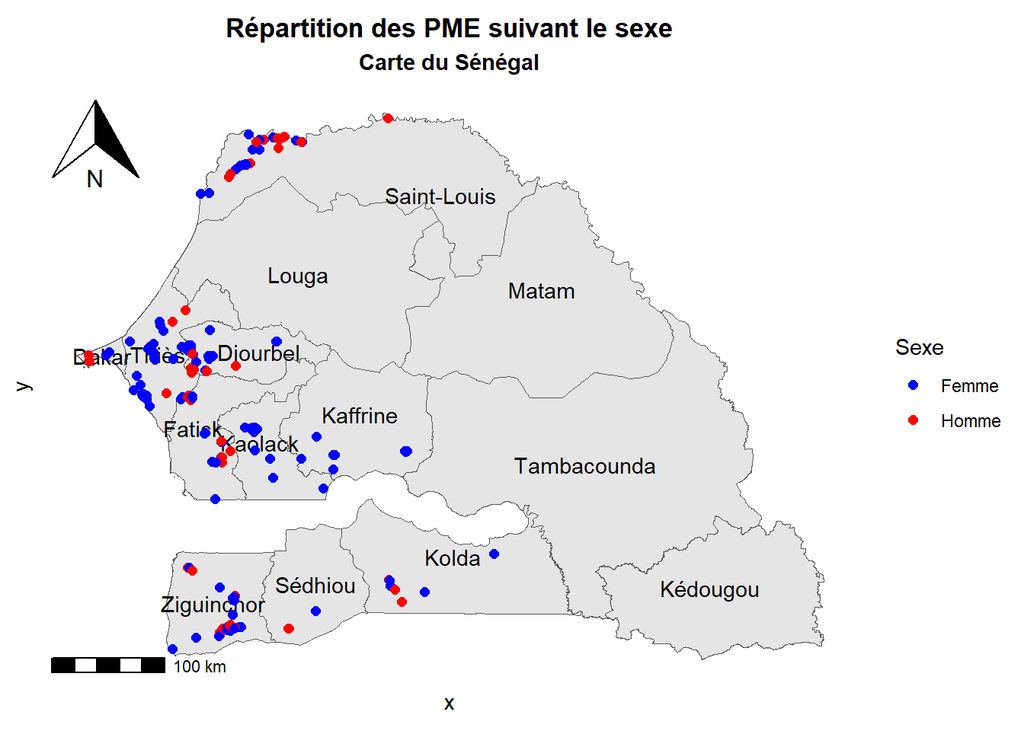

```r
# Création de la première carte avec la répartition des PME suivant le sexe
ggplot() +
  geom_sf(data=senegal)+
  geom_sf_text(data=senegal, aes(label=NAME_1))+
  geom_sf(data=projet_map, aes(color=sexe), size=2)+
  scale_color_manual(values=c("blue", "red"))+
  labs(title = "Répartition des PME suivant le sexe",
       subtitle = "Carte du Sénégal",
       color = "Sexe") +
  theme_minimal() +
  theme(
    plot.title = element_text(hjust = 0.5, face = "bold"),
    plot.subtitle = element_text(hjust = 0.5, face = "bold"))+
  coord_sf(datum = NA)+
  annotation_scale(location = "bl", text_col = "black")+
  annotation_north_arrow(location = "tl")
```

• Représentation spatiale des PME suivant le niveau d’instruction:

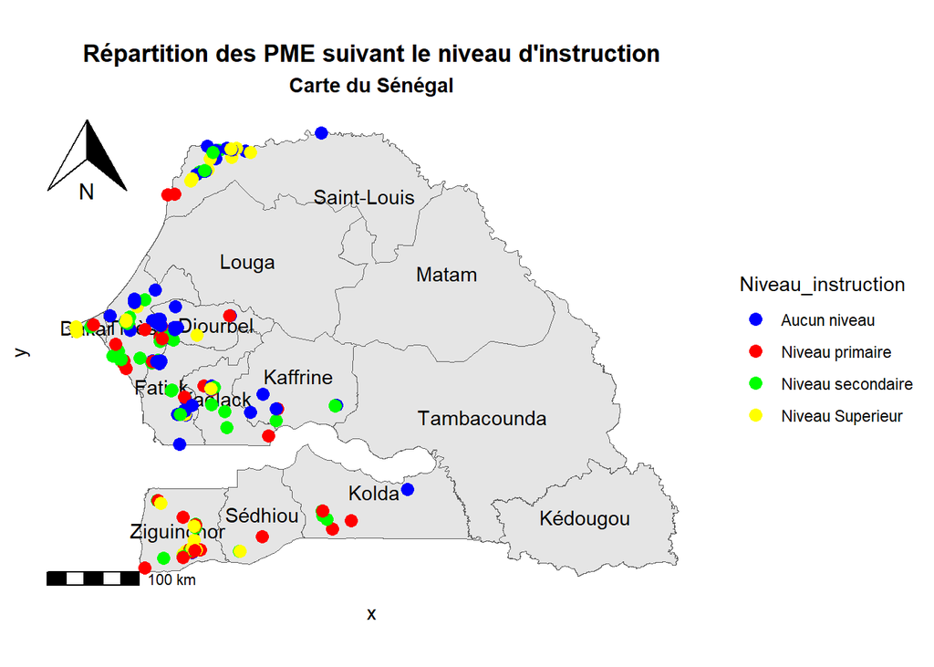

```r
# Renommons la variable q25 en Niveau_instruction
projet_map <- projet_map %>% rename(Niveau_instruction = q25)

# Création de la deuxième carte avec la répartition des PME
# suivant le niveau d'instruction
ggplot() +
  geom_sf(data=senegal)+
  geom_sf_text(data=senegal, aes(label=NAME_1))+
  geom_sf(data = projet_map, aes(color = Niveau_instruction), size =3) +
  scale_color_manual(values=c("blue", "red", "green", "yellow")) +
  labs(title = "Répartition des PME suivant le niveau d'instruction",
       subtitle = "Carte du Sénégal") +
  theme_minimal() +
  theme(
    plot.title = element_text(hjust = 0.5, face = "bold"),
    plot.subtitle = element_text(hjust = 0.5, face = "bold"))+
  coord_sf(datum = NA)+
  annotation_scale(location = "bl", text_col = "black")+
  annotation_north_arrow(location = "tl")
```

# Partie 2

## 1 Nettoyage et gestion des données

• Chargeons les données et effectuons le nettoyage initial

```r
# Chargement les données
feuille1 <- read_excel("Bases/Base_Partie 2.xlsx", sheet = 1)

# Renommons la variable "country_destination" en "destination" et
# définissons les valeurs négatives comme manquantes
feuille1 <- feuille1 %>%
  rename(destination = country_destination) %>%
  mutate(destination = ifelse(destination < 0, NA, destination))
```

• Création d’une nouvelle variable contenant des tranches d’âge de 5 ans

```r
feuille1 <- feuille1 %>%
  mutate(tranche_age = cut(age, breaks = seq(0, max(age), by = 5), include.lowest = TRUE))
```

• Création d’une nouvelle variable contenant le nombre d’entretiens réalisés par chaque agent recenseur :

```r
feuille1 <- feuille1 %>%
  group_by(enumerator) %>%
  mutate(nombre_entretiens = n()) %>%
  ungroup()
```

Créer une nouvelle variable qui affecte aléatoirement chaque répondant à un groupe de traitement (1) ou de contrôle (0)

```r
feuille1 <- feuille1 %>%
  mutate(groupe = {set.seed(123); sample(c(0, 1), size = n(), replace = TRUE)})
```

Fusionner la taille de la population de chaque district (feuille 2) avec l’ensemble de données (feuille 1) :

```r
# Charger les données de la deuxième feuille
feuille2 <- read_excel("Bases/Base_Partie 2.xlsx", sheet = 2)

# Fusion
feuille1 <- feuille1 %>%
  left_join(feuille2, by = "district")
```

Calculer la durée de l’entretien et indiquer la durée moyenne de l’entretien par enquêteur :

```r
feuille1 <- feuille1 %>%
  mutate(duree_entretien = endtime - starttime) %>%
  group_by(enumerator) %>%
  mutate(duree_moyenne_entretien = mean(duree_entretien)) %>%
  ungroup()
```

Renommer toutes les variables de l’ensemble de données en ajoutant le préfixe “endline_” à l’aide d’une boucle :

```r
copie = feuille1
feuille1 <- feuille1 %>%
  rename_all(~paste0("endline_", .))
```

## 2 Analyse et visualisation des données

• Création d’un tableau récapitulatif contenant l’âge moyen et le nombre moyen d’enfants par district :

```r
feuille1 %>%
  tbl_summary(
    by = endline_district,
    include = c("endline_age", "endline_children_num"),
    type = list(endline_children_num = "continuous"),
    statistic = all_continuous() ~ "{mean}",
    label=list( endline_age~ "Age moyen",
                endline_children_num ~ "Nombre moyen d'enfants")
    ) %>%
  add_overall(last = TRUE) %>%
  modify_header(label ~ "**Caractéristiques**") %>%
  modify_spanning_header(all_stat_cols() ~ "**District**") %>%
  bold_labels()
```

| **Caractéristiques** | **District** **1**, N = 8<sup>1</sup> | **District** **2**, N = 27<sup>1</sup> | **District** **3**, N = 8<sup>1</sup> | **District** **4**, N = 5<sup>1</sup> | **District** **5**, N = 6<sup>1</sup> | **District** **6**, N = 26<sup>1</sup> | **District** **7**, N = 6<sup>1</sup> | **District** **8**, N = 11<sup>1</sup> | **District** **Overall**, N = 97<sup>1</sup> |
| --- | --- | --- | --- | --- | --- | --- | --- | --- | --- |
| Age moyen | 30 | 63 | 26 | 26 | 24 | 23 | 28 | 25 | 36 |
| Nombre moyen d'enfants | 1.50 | 0.85 | 0.00 | 0.00 | 0.50 | 0.12 | 0.17 | 1.27 | 0.58 |

<sup>1</sup> Mean

• Estimation de l’effet de l’appartenance au groupe de traitement sur l’intention de migrer:

```r
library(nnet)
regm <- multinom(intention ~ groupe ,data = copie)
tbl <- tbl_regression(regm, exponentiate = TRUE)
tbl
```

| **Characteristic** | **OR**<sup>1</sup> | **95% CI**<sup>1</sup> | **p-value** |
| --- | --- | --- | --- |
| 2 |  |  |  |
| groupe | 0.47 | 0.05, 4.82 | 0.5 |
| 3 |  |  |  |
| groupe | 0.61 | 0.14, 2.58 | 0.5 |
| 4 |  |  |  |
| groupe | 3.56 | 0.64, 19.8 | 0.15 |
| 5 |  |  |  |
| groupe | 1.42 | 0.27, 7.61 | 0.7 |
| 6 |  |  |  |
| groupe | 5.69 | 0.60, 53.9 | 0.13 |
| 7 |  |  |  |
| groupe | 0.00 | 0.00, Inf | >0.9 |

<sup>1</sup> OR = Odds Ratio, CI = Confidence Interval

```r
library(GGally)
ggcoef_multinom(
  regm,
  exponentiate = TRUE
)
```

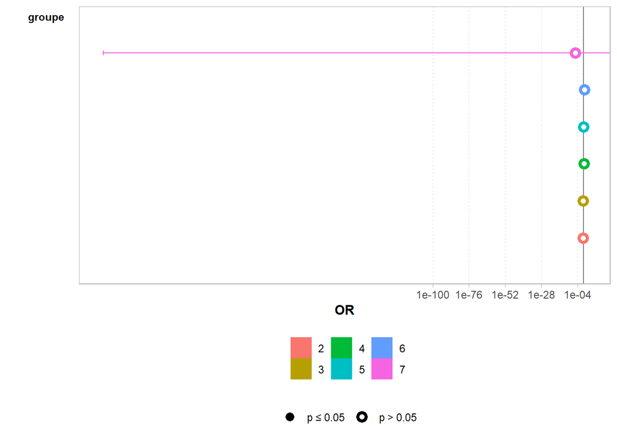

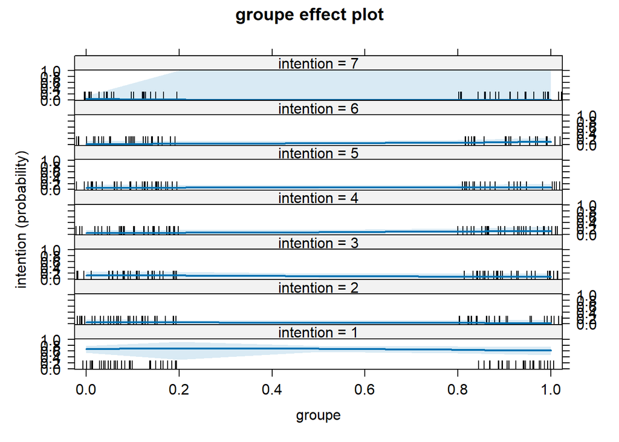

```r
library(effects)
plot(allEffects(regm))
```

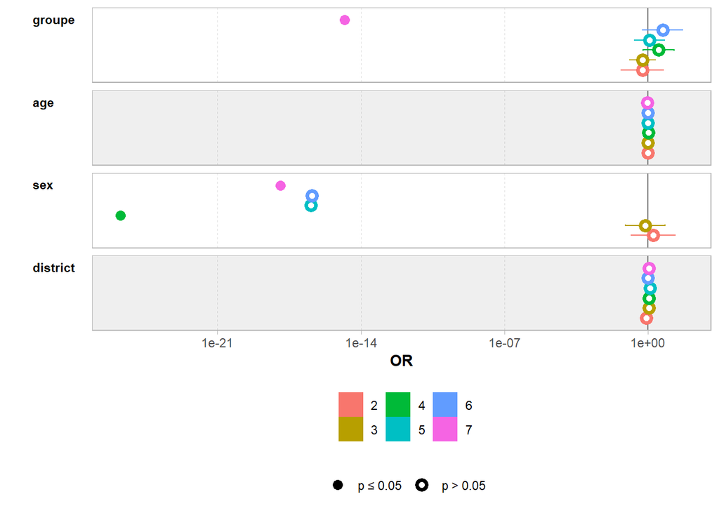

```r
# Modèle A : Modèle vide - Effet du traitement sur les intentions
modele_A <- multinom(intention ~ groupe, data = copie)
tableau_A <- tbl_regression(modele_A)

# Modèle B : Effet du traitement sur les intentions en tenant compte de l'âge et du sexe
modele_B <- multinom(intention ~ groupe + age + sex, data = copie)
tableau_B <- tbl_regression(modele_B)

# Modèle C : Identique au modèle B mais en contrôlant le district
modele_C <- multinom(intention ~ groupe + age + sex + district, data = copie)
ggcoef_multinom(
  modele_C,
  exponentiate = TRUE)
```

[figure not shown]

```r
plot(allEffects(modele_C))
```

```r
tableau_C <- tbl_regression(modele_C)

# Création du tableau récapitulatif des résultats des trois modèles
tableau_final <- tbl_merge(list(tableau_A, tableau_B, tableau_C),
              tab_spanner = c("Modèle A","Modèle B","Modèle C"))

# Affichage du tableau final
tableau_final
```

| **Characteristic** | Modèle A **Outcome** | Modèle A **log(OR)**<sup>1</sup> | Modèle A **95% CI**<sup>1</sup> | Modèle A **p-value** | Modèle B **Outcome** | Modèle B **log(OR)**<sup>1</sup> | Modèle B **95% CI**<sup>1</sup> | Modèle B **p-value** | Modèle C **Outcome** | Modèle C **log(OR)**<sup>1</sup> | Modèle C **95% CI**<sup>1</sup> | Modèle C **p-value** |
| --- | --- | --- | --- | --- | --- | --- | --- | --- | --- | --- | --- | --- |
| groupe | 2 | -0.75 | -3.1, 1.6 | 0.5 | 2 | -0.73 | -3.1, 1.6 | 0.5 | 2 | -0.63 | -3.0, 1.7 | 0.6 |
| groupe | 2 | -0.75 | -3.1, 1.6 | 0.5 | 2 | -0.73 | -3.1, 1.6 | 0.5 | 3 | -0.61 | -2.1, 0.85 | 0.4 |
| groupe | 2 | -0.75 | -3.1, 1.6 | 0.5 | 2 | -0.73 | -3.1, 1.6 | 0.5 | 4 | 1.2 | -0.55, 3.0 | 0.2 |
| groupe | 2 | -0.75 | -3.1, 1.6 | 0.5 | 2 | -0.73 | -3.1, 1.6 | 0.5 | 5 | 0.18 | -1.5, 1.9 | 0.8 |
| groupe | 2 | -0.75 | -3.1, 1.6 | 0.5 | 2 | -0.73 | -3.1, 1.6 | 0.5 | 6 | 1.7 | -0.62, 3.9 | 0.2 |
| groupe | 2 | -0.75 | -3.1, 1.6 | 0.5 | 2 | -0.73 | -3.1, 1.6 | 0.5 | 7 | -34 | -34, -34 | <0.001 |
| groupe | 2 | -0.75 | -3.1, 1.6 | 0.5 | 3 | -0.54 | -2.0, 0.91 | 0.5 | 2 | -0.63 | -3.0, 1.7 | 0.6 |
| groupe | 2 | -0.75 | -3.1, 1.6 | 0.5 | 3 | -0.54 | -2.0, 0.91 | 0.5 | 3 | -0.61 | -2.1, 0.85 | 0.4 |
| groupe | 2 | -0.75 | -3.1, 1.6 | 0.5 | 3 | -0.54 | -2.0, 0.91 | 0.5 | 4 | 1.2 | -0.55, 3.0 | 0.2 |
| groupe | 2 | -0.75 | -3.1, 1.6 | 0.5 | 3 | -0.54 | -2.0, 0.91 | 0.5 | 5 | 0.18 | -1.5, 1.9 | 0.8 |
| groupe | 2 | -0.75 | -3.1, 1.6 | 0.5 | 3 | -0.54 | -2.0, 0.91 | 0.5 | 6 | 1.7 | -0.62, 3.9 | 0.2 |
| groupe | 2 | -0.75 | -3.1, 1.6 | 0.5 | 3 | -0.54 | -2.0, 0.91 | 0.5 | 7 | -34 | -34, -34 | <0.001 |
| groupe | 2 | -0.75 | -3.1, 1.6 | 0.5 | 4 | 1.2 | -0.50, 3.0 | 0.2 | 2 | -0.63 | -3.0, 1.7 | 0.6 |
| groupe | 2 | -0.75 | -3.1, 1.6 | 0.5 | 4 | 1.2 | -0.50, 3.0 | 0.2 | 3 | -0.61 | -2.1, 0.85 | 0.4 |
| groupe | 2 | -0.75 | -3.1, 1.6 | 0.5 | 4 | 1.2 | -0.50, 3.0 | 0.2 | 4 | 1.2 | -0.55, 3.0 | 0.2 |
| groupe | 2 | -0.75 | -3.1, 1.6 | 0.5 | 4 | 1.2 | -0.50, 3.0 | 0.2 | 5 | 0.18 | -1.5, 1.9 | 0.8 |
| groupe | 2 | -0.75 | -3.1, 1.6 | 0.5 | 4 | 1.2 | -0.50, 3.0 | 0.2 | 6 | 1.7 | -0.62, 3.9 | 0.2 |
| groupe | 2 | -0.75 | -3.1, 1.6 | 0.5 | 4 | 1.2 | -0.50, 3.0 | 0.2 | 7 | -34 | -34, -34 | <0.001 |
| groupe | 2 | -0.75 | -3.1, 1.6 | 0.5 | 5 | 0.26 | -1.4, 1.9 | 0.8 | 2 | -0.63 | -3.0, 1.7 | 0.6 |
| groupe | 2 | -0.75 | -3.1, 1.6 | 0.5 | 5 | 0.26 | -1.4, 1.9 | 0.8 | 3 | -0.61 | -2.1, 0.85 | 0.4 |
| groupe | 2 | -0.75 | -3.1, 1.6 | 0.5 | 5 | 0.26 | -1.4, 1.9 | 0.8 | 4 | 1.2 | -0.55, 3.0 | 0.2 |
| groupe | 2 | -0.75 | -3.1, 1.6 | 0.5 | 5 | 0.26 | -1.4, 1.9 | 0.8 | 5 | 0.18 | -1.5, 1.9 | 0.8 |
| groupe | 2 | -0.75 | -3.1, 1.6 | 0.5 | 5 | 0.26 | -1.4, 1.9 | 0.8 | 6 | 1.7 | -0.62, 3.9 | 0.2 |
| groupe | 2 | -0.75 | -3.1, 1.6 | 0.5 | 5 | 0.26 | -1.4, 1.9 | 0.8 | 7 | -34 | -34, -34 | <0.001 |
| groupe | 2 | -0.75 | -3.1, 1.6 | 0.5 | 6 | 1.6 | -0.61, 3.9 | 0.2 | 2 | -0.63 | -3.0, 1.7 | 0.6 |
| groupe | 2 | -0.75 | -3.1, 1.6 | 0.5 | 6 | 1.6 | -0.61, 3.9 | 0.2 | 3 | -0.61 | -2.1, 0.85 | 0.4 |
| groupe | 2 | -0.75 | -3.1, 1.6 | 0.5 | 6 | 1.6 | -0.61, 3.9 | 0.2 | 4 | 1.2 | -0.55, 3.0 | 0.2 |
| groupe | 2 | -0.75 | -3.1, 1.6 | 0.5 | 6 | 1.6 | -0.61, 3.9 | 0.2 | 5 | 0.18 | -1.5, 1.9 | 0.8 |
| groupe | 2 | -0.75 | -3.1, 1.6 | 0.5 | 6 | 1.6 | -0.61, 3.9 | 0.2 | 6 | 1.7 | -0.62, 3.9 | 0.2 |
| groupe | 2 | -0.75 | -3.1, 1.6 | 0.5 | 6 | 1.6 | -0.61, 3.9 | 0.2 | 7 | -34 | -34, -34 | <0.001 |

[output cut: 264 more lines]

<sup>1</sup> OR = Odds Ratio, CI = Confidence Interval